# An R Markdown document converted from “notebook.ipynb”

## 1. Importing data part 1

What an exciting [FIFA Women’s World Cup](https://www.fifa.com/womensworldcup/)! Congratulations to the [US Women’s National Team](https://www.ussoccer.com/teams/uswnt) and to all the [national teams](https://www.fifa.com/womensworldcup/teams/) who made the tournament such a great event!

[figure not shown]

*Source: [Wikimedia Commons](https://commons.wikimedia.org/wiki/File:Football_pictogram.svg)*

Now that the tournament is over, our boss at *Crunching Numbers* needs to know which match/stadium had the highest attendance during the women’s world cup. Thankfully, one of our trusty interns, Bob, already has the data for us. After chatting with Bob about his football (soccer in the US) obsession, we learned that he collected the data by either watching the games or reading the [FIFA Women’s World Cup match reports](https://www.fifa.com/womensworldcup/matches/?#groupphase). He manually entered the data into a flat file (.csv) and emailed it to us.

Let’s read in the file and explore the raw data!

```r
# In this project code scaffolding will only be given for functions that were not
# explained in the prerequisite courses. Look at the hints if you need help.

# Load the packages
# .... YOUR CODE FOR TASK 1 ....

library(readr)
library(dplyr)
# Read in the data from the datasets folder
# .... YOUR CODE FOR TASK 1 ....
wwc_raw <- read_csv("datasets/2019_WWCFIFA_summary.csv")
# Check the dimensions and structure of the data
# .... YOUR CODE FOR TASK 1 ....
glimpse(wwc_raw)
```

```
## Rows: 55
## Columns: 13
## $ Round      <chr> "Group stage", "Group stage", "Group stage", "Group stage",…
## $ Wk         <chr> "1", "1", "1", "1", "1", "1", "1", "1", "1", "1", "1", "1",…
## $ Day        <chr> "Fri", "Sat", "Sat", "Sat", "Sun", "Sun", "Sun", "Mon", "Mo…
## $ Date       <chr> "06/07/19", "06/08/19", "06/08/19", "06/08/19", "06/09/19",…
## $ Time       <time> 21:00:00, 15:00:00, 18:00:00, 21:00:00, 13:00:00, 15:30:00…
## $ Home       <chr> "France", "Germany", "Spain", "Norway", "Australia", "Brazi…
## $ Score      <chr> "4 - 0", "1 - 0", "3 - 1", "3 - 0", "1 - 2", "3 - 0", "2 - …
## $ PKS        <chr> NA, NA, NA, NA, NA, NA, NA, NA, NA, NA, NA, NA, NA, NA, NA,…
## $ Away       <chr> "Korea Rep", "China PR", "South Africa", "Nigeria", "Italy"…
## $ Attendance <dbl> 45261, 15283, 12044, 11058, 15380, 17668, 13188, 25055, 107…
## $ Venue      <chr> "Parc des Princes", "Roazhon Park", "Stade Oceane", "Stade …
## $ Referee    <chr> "Claudia Umpierrez", "Marie-Soleil Beaudoin", "Maria Carvaj…
## $ Notes      <chr> NA, NA, NA, NA, NA, NA, NA, NA, NA, NA, NA, NA, NA, NA, NA,…
```

```r
summary(wwc_raw)
```

```
##     Round                Wk                Day                Date
##  Length:55          Length:55          Length:55          Length:55
##  Class :character   Class :character   Class :character   Class :character
##  Mode  :character   Mode  :character   Mode  :character   Mode  :character
##
##
##
##
##      Time              Home              Score               PKS
##  Length:55         Length:55          Length:55          Length:55
##  Class1:hms        Class :character   Class :character   Class :character
##  Class2:difftime   Mode  :character   Mode  :character   Mode  :character
##  Mode  :numeric
##
##
##
##      Away             Attendance        Venue             Referee
##  Length:55          Min.   :  8009   Length:55          Length:55
##  Class :character   1st Qu.: 13476   Class :character   Class :character
##  Mode  :character   Median : 18934   Mode  :character   Mode  :character
##                     Mean   : 31777
##                     3rd Qu.: 22941
##                     Max.   :579000
##                     NA's   :3
##     Notes
##  Length:55
##  Class :character
##  Mode  :character
##
##
##
##
```

```r
str(wwc_raw)
```

```
## spec_tbl_df [55 × 13] (S3: spec_tbl_df/tbl_df/tbl/data.frame)
##  $ Round     : chr [1:55] "Group stage" "Group stage" "Group stage" "Group stage" ...
##  $ Wk        : chr [1:55] "1" "1" "1" "1" ...
##  $ Day       : chr [1:55] "Fri" "Sat" "Sat" "Sat" ...
##  $ Date      : chr [1:55] "06/07/19" "06/08/19" "06/08/19" "06/08/19" ...
##  $ Time      : 'hms' num [1:55] 21:00:00 15:00:00 18:00:00 21:00:00 ...
##   ..- attr(*, "units")= chr "secs"
##  $ Home      : chr [1:55] "France" "Germany" "Spain" "Norway" ...
##  $ Score     : chr [1:55] "4 - 0" "1 - 0" "3 - 1" "3 - 0" ...
##  $ PKS       : chr [1:55] NA NA NA NA ...
##  $ Away      : chr [1:55] "Korea Rep" "China PR" "South Africa" "Nigeria" ...
##  $ Attendance: num [1:55] 45261 15283 12044 11058 15380 ...
##  $ Venue     : chr [1:55] "Parc des Princes" "Roazhon Park" "Stade Oceane" "Stade Auguste-Delaune II" ...
##  $ Referee   : chr [1:55] "Claudia Umpierrez" "Marie-Soleil Beaudoin" "Maria Carvajal" "Kate Jacewicz" ...
##  $ Notes     : chr [1:55] NA NA NA NA ...
##  - attr(*, "spec")=
##   .. cols(
##   ..   Round = col_character(),
##   ..   Wk = col_character(),
##   ..   Day = col_character(),
##   ..   Date = col_character(),
##   ..   Time = col_time(format = ""),
##   ..   Home = col_character(),
##   ..   Score = col_character(),
##   ..   PKS = col_character(),
##   ..   Away = col_character(),
##   ..   Attendance = col_double(),
##   ..   Venue = col_character(),
##   ..   Referee = col_character(),
##   ..   Notes = col_character()
##   .. )
##  - attr(*, "problems")=<externalptr>
```

## 2. Importing data part 2

Looking at the outputs, we notice a few things about the data. First, we have some `NA`s to address. Second, most of the columns are of type `character`. One of the differences between `read_csv()` (`readr`) and `read.csv()` (`utils`) is how character strings are treated. With `read.csv()` strings are coerced to factors, while in `read_csv()` strings are not coerced. Let’s import the data again, but this time, we will assign data types to the `Round`, `Date`, and `Venue` columns.

**Instructor’s note**: My apologies for several incorrect spellings. Stade Oceane should be *Stade Océane*. The correct spellings of the names of the referees are *Stéphanie Frappart*, *Katalin Kulcsár*, and *Claudia Umpiérrez*. Accents are not currently supported in Jupyter Notebook outputs on DataCamp and had to be removed from the data file.

```r
# Read in the data specifying column types
wwc_raw <- read_csv("datasets/2019_WWCFIFA_summary.csv",
                col_types = cols(
                                Round = col_factor(),
                                Date = col_date(format = "%m/%d/%y"),
                                Venue = col_factor()
                                  )
                 )

# Look at the summary and structure of the data
# .... YOUR CODE FOR TASK 2 ....
glimpse(wwc_raw)
```

```
## Rows: 55
## Columns: 13
## $ Round      <fct> Group stage, Group stage, Group stage, Group stage, Group s…
## $ Wk         <chr> "1", "1", "1", "1", "1", "1", "1", "1", "1", "1", "1", "1",…
## $ Day        <chr> "Fri", "Sat", "Sat", "Sat", "Sun", "Sun", "Sun", "Mon", "Mo…
## $ Date       <date> 2019-06-07, 2019-06-08, 2019-06-08, 2019-06-08, 2019-06-09…
## $ Time       <time> 21:00:00, 15:00:00, 18:00:00, 21:00:00, 13:00:00, 15:30:00…
## $ Home       <chr> "France", "Germany", "Spain", "Norway", "Australia", "Brazi…
## $ Score      <chr> "4 - 0", "1 - 0", "3 - 1", "3 - 0", "1 - 2", "3 - 0", "2 - …
## $ PKS        <chr> NA, NA, NA, NA, NA, NA, NA, NA, NA, NA, NA, NA, NA, NA, NA,…
## $ Away       <chr> "Korea Rep", "China PR", "South Africa", "Nigeria", "Italy"…
## $ Attendance <dbl> 45261, 15283, 12044, 11058, 15380, 17668, 13188, 25055, 107…
## $ Venue      <fct> Parc des Princes, Roazhon Park, Stade Oceane, Stade Auguste…
## $ Referee    <chr> "Claudia Umpierrez", "Marie-Soleil Beaudoin", "Maria Carvaj…
## $ Notes      <chr> NA, NA, NA, NA, NA, NA, NA, NA, NA, NA, NA, NA, NA, NA, NA,…
```

```r
summary(wwc_raw)
```

```
##              Round         Wk                Day
##  Group stage    :36   Length:55          Length:55
##                 : 3   Class :character   Class :character
##  Round of 16    : 8   Mode  :character   Mode  :character
##  Quarterfinals  : 4
##  Semifinals     : 2
##  3rd-place match: 1
##  Final          : 1
##       Date                Time              Home              Score
##  Min.   :2019-06-07   Length:55         Length:55          Length:55
##  1st Qu.:2019-06-12   Class1:hms        Class :character   Class :character
##  Median :2019-06-17   Class2:difftime   Mode  :character   Mode  :character
##  Mean   :2019-06-18   Mode  :numeric
##  3rd Qu.:2019-06-23
##  Max.   :2019-07-07
##  NA's   :4
##      PKS                Away             Attendance
##  Length:55          Length:55          Min.   :  8009
##  Class :character   Class :character   1st Qu.: 13476
##  Mode  :character   Mode  :character   Median : 18934
##                                        Mean   : 31777
##                                        3rd Qu.: 22941
##                                        Max.   :579000
##                                        NA's   :3
##                       Venue      Referee             Notes
##  Parc des Princes        : 7   Length:55          Length:55
##  Roazhon Park            : 7   Class :character   Class :character
##  Stade Oceane            : 7   Mode  :character   Mode  :character
##  Stade Auguste-Delaune II: 6
##  Stade du Hainaut        : 6
##  Stade de Nice           : 6
##  (Other)                 :16
```

```r
# Print the dataset
# .... YOUR CODE FOR TASK 2 ....
wwc_raw
```

```
## # A tibble: 55 × 13
##    Round   Wk    Day   Date       Time  Home  Score PKS   Away  Attendance Venue
##    <fct>   <chr> <chr> <date>     <tim> <chr> <chr> <chr> <chr>      <dbl> <fct>
##  1 Group … 1     Fri   2019-06-07 21:00 Fran… 4 - 0 <NA>  Kore…      45261 Parc…
##  2 Group … 1     Sat   2019-06-08 15:00 Germ… 1 - 0 <NA>  Chin…      15283 Roaz…
##  3 Group … 1     Sat   2019-06-08 18:00 Spain 3 - 1 <NA>  Sout…      12044 Stad…
##  4 Group … 1     Sat   2019-06-08 21:00 Norw… 3 - 0 <NA>  Nige…      11058 Stad…
##  5 Group … 1     Sun   2019-06-09 13:00 Aust… 1 - 2 <NA>  Italy      15380 Stad…
##  6 Group … 1     Sun   NA         15:30 Braz… 3 - 0 <NA>  Jama…      17668 Stad…
##  7 Group … 1     Sun   2019-06-09 18:00 Engl… 2 - 1 <NA>  Scot…      13188 Stad…
##  8 Group … 1     Mon   2019-06-10 18:00 Arge… 0 - 0 <NA>  Japan      25055 Parc…
##  9 Group … 1     Mon   2019-06-10 21:00 Cana… 1 - 0 <NA>  Came…      10710 Stad…
## 10 Group … 1     Tue   2019-06-11 15:00 New … 0 - 1 <NA>  Neth…      10654 Stad…
## # … with 45 more rows, and 2 more variables: Referee <chr>, Notes <chr>
```

## 3. Removing rows of NA

We have 55 observations (rows) of 13 variables (columns). Hmmm, we know there were 52 games - why the extra rows? Also `Round` and `Attendance` each have three `NA`, and `Date` and `Venue` each have four `NA`. It looks like we have a few things to fix.

- Rows of NA
- Missing data values
- Multiple values in one column (look at `Score` and `PKS`)
- Column headers are a mix of upper- and lowercase letters

The last issue is more of a preference. Having all the column names in the same case will make typing easier.

Great hustle on Bob’s part for collecting the information we need, but he gets a yellow card for inserting the rows of `NA`. Let’s start cleaning the data by putting the column names in lowercase and removing the rows of `NA`.

```r
# load the package
# .... YOUR CODE FOR TASK 2 ....
library(tidyr)
# Remove rows of NA
wwc_1  <- wwc_raw  %>%
 rename_all(tolower)  %>%
 # .... YOUR CODE FOR TASK 2 ....
 filter(!is.na(round))
# Get the dimensions and inspect the first 10 and last 10 rows
 # .... YOUR CODE FOR TASK 2 ....
dim(wwc_1)
```

```
## [1] 55 13
```

```r
head(wwc_1, n = 10)
```

```
## # A tibble: 10 × 13
##    round   wk    day   date       time  home  score pks   away  attendance venue
##    <fct>   <chr> <chr> <date>     <tim> <chr> <chr> <chr> <chr>      <dbl> <fct>
##  1 Group … 1     Fri   2019-06-07 21:00 Fran… 4 - 0 <NA>  Kore…      45261 Parc…
##  2 Group … 1     Sat   2019-06-08 15:00 Germ… 1 - 0 <NA>  Chin…      15283 Roaz…
##  3 Group … 1     Sat   2019-06-08 18:00 Spain 3 - 1 <NA>  Sout…      12044 Stad…
##  4 Group … 1     Sat   2019-06-08 21:00 Norw… 3 - 0 <NA>  Nige…      11058 Stad…
##  5 Group … 1     Sun   2019-06-09 13:00 Aust… 1 - 2 <NA>  Italy      15380 Stad…
##  6 Group … 1     Sun   NA         15:30 Braz… 3 - 0 <NA>  Jama…      17668 Stad…
##  7 Group … 1     Sun   2019-06-09 18:00 Engl… 2 - 1 <NA>  Scot…      13188 Stad…
##  8 Group … 1     Mon   2019-06-10 18:00 Arge… 0 - 0 <NA>  Japan      25055 Parc…
##  9 Group … 1     Mon   2019-06-10 21:00 Cana… 1 - 0 <NA>  Came…      10710 Stad…
## 10 Group … 1     Tue   2019-06-11 15:00 New … 0 - 1 <NA>  Neth…      10654 Stad…
## # … with 2 more variables: referee <chr>, notes <chr>
```

```r
tail(wwc_1, n = 10)
```

```
## # A tibble: 10 × 13
##    round   wk    day   date       time  home  score pks   away  attendance venue
##    <fct>   <chr> <chr> <date>     <tim> <chr> <chr> <chr> <chr>      <dbl> <fct>
##  1 Round … R16   Tue   2019-06-25 18:00 Italy 2 - 0 <NA>  Chin…      17492 "Sta…
##  2 Round … R16   Tue   2019-06-25 21:00 Neth… 2 - 1 <NA>  Japan      21076 "Roa…
##  3 Quarte… QRTF  Thu   2019-06-27 21:00 Norw… 0 - 3 <NA>  Engl…      21111 "Sta…
##  4 Quarte… QRTF  Fri   2019-06-28 21:00 Fran… 1 - 2 <NA>  USA        45595 "Par…
##  5 Quarte… QRTF  Sat   2019-06-29 15:00 Italy 0 - 2 <NA>  Neth…      22600 "Sta…
##  6 Quarte… QRTF  Sat   2019-06-29 18:30 Germ… 1 - 2 <NA>  Swed…      25301 "Roa…
##  7 Semifi… SMIF  Tue   2019-07-02 21:00 Engl… 1 - 2 <NA>  USA        53512 ""
##  8 Semifi… SMIF  Wed   2019-07-03 21:00 Neth… 1 - 0 <NA>  Swed…      48452 "Gro…
##  9 3rd-pl… 3rd   Sat   2019-07-06 17:00 Engl… 1 - 2 <NA>  Swed…      20316 "Sta…
## 10 Final   FIN   Sun   2019-07-07 17:00 USA   2 - 0 <NA>  Neth…     579000 "Gro…
## # … with 2 more variables: referee <chr>, notes <chr>
```

## 4. Replacing NA

[figure not shown]

```r
# Housekeeping
wwc_2  <- wwc_1

# Find, view, and replace NA in column date
index_date  <- which(is.na(wwc_2$date))
# .... YOUR CODE FOR TASK 4 ....
wwc_2$date[index_date]  <- "2019-06-09"

# Find, view, and replace NA in column venue
index_venue  <- which(is.na(wwc_2$venue))
# .... YOUR CODE FOR TASK 4 ....
wwc_2$venue[index_venue] <- "Groupama Stadium"
#colSums(is.na(wwc_2))
```

## 5. separate() and replace_na()

All right! The data are looking good, but it is a good idea to get the two data points in `score` and two data points in `pks` into their own columns for future data sleuthing.

For this task we’re going to employ the functionality of `separate()`, `mutate()`, and `replace_na()`. Look back at the directions in Task 4 to see an example of how `mutate()` and `replace_na()` are used together. We’ll use the pipe operator, `%`, to pipe the functions together for readability.

```r
# Separate columns and replace NA (you've got this!)
wwc_3  <- wwc_2  %>%
  # .... YOUR CODE FOR TASK 5 ....
 separate(score, c("home_score", "away_score"),sep = "-", convert = TRUE) %>%
 separate(pks, c("home_pks", "away_pks"), sep = "-", convert = TRUE) %>%
 replace_na(list("home_pks" = 0, "away_pks" = 0))
# Print the data
# .... YOUR CODE FOR TASK 5 ....
wwc_3
```

```
## # A tibble: 55 × 15
##    round       wk    day   date       time  home  home_score away_score home_pks
##    <fct>       <chr> <chr> <date>     <tim> <chr>      <dbl>      <int>    <dbl>
##  1 Group stage 1     Fri   2019-06-07 21:00 Fran…          4          0        0
##  2 Group stage 1     Sat   2019-06-08 15:00 Germ…          1          0        0
##  3 Group stage 1     Sat   2019-06-08 18:00 Spain          3          1        0
##  4 Group stage 1     Sat   2019-06-08 21:00 Norw…          3          0        0
##  5 Group stage 1     Sun   2019-06-09 13:00 Aust…          1          2        0
##  6 Group stage 1     Sun   2019-06-09 15:30 Braz…          3          0        0
##  7 Group stage 1     Sun   2019-06-09 18:00 Engl…          2          1        0
##  8 Group stage 1     Mon   2019-06-10 18:00 Arge…          0          0        0
##  9 Group stage 1     Mon   2019-06-10 21:00 Cana…          1          0        0
## 10 Group stage 1     Tue   2019-06-11 15:00 New …          0          1        0
## # … with 45 more rows, and 6 more variables: away_pks <int>, away <chr>,
## #   attendance <dbl>, venue <fct>, referee <chr>, notes <chr>
```

## 6. Plotting for outliers

Now we can take a look at `attendance` and find the information the boss wants. Let’s plot the data to see if there are any outliers.

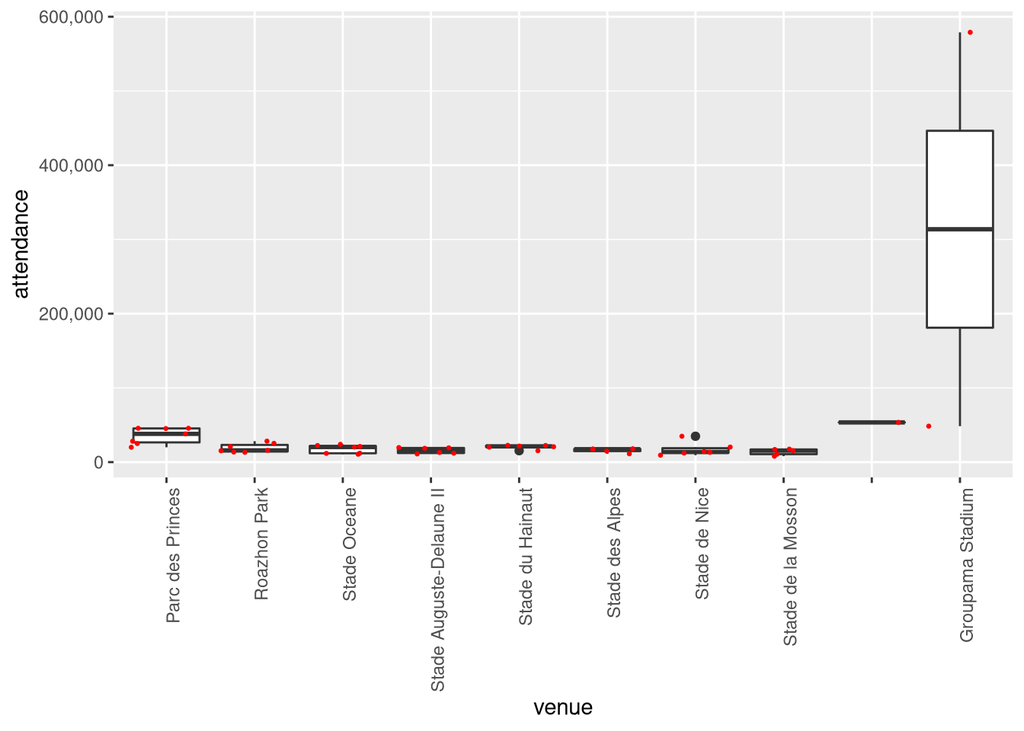

```r
# Housekeeping for plot size
options(repr.plot.width=6, repr.plot.height=4)

# Load the package
# .... YOUR CODE FOR TASK 6 ....
library(ggplot2)
# Make a boxplot of attendance by venue and add the point data
# .... YOUR CODE FOR TASK 6 ....
# .... YOUR CODE FOR TASK 6 ....
wwc_3 %>%
ggplot(aes(x = venue, y = attendance)) +
  geom_boxplot() +
  geom_jitter(color = "red", size = 0.5) +
  theme(axis.text.x = element_text(angle = 90, hjust = 1)) +
  scale_y_continuous(labels = scales::comma)
```

## 7. What to do with the outlier?

Whoa! What’s up with the attendance for Groupama Stadium? One data point is almost 600,000 (6e+05*) while all the other data points are less than 100,000. That does not seem right.

After chatting with Bob about the outlier and checking the match report, we learned that Bob mistakenly added an extra 0. We can fix that! Let’s summarize the attendance by the venue, fix the outlier, and create a new summary table with the updated data.

`*` For fun, add

```
scale_y_continuous(labels =
scales::comma)
```

as the last line of the call to `ggplot()` in Task 6 and see how the y-axis value labels change.

```r
# Summarize the number of games, and min and max attendance for each venue
wwc_3  %>%
  # .... YOUR CODE FOR TASK 7 ....
  group_by(venue) %>%
  summarise(min = min(attendance),
            max = max(attendance))
```

```
## # A tibble: 10 × 3
##    venue                        min    max
##    <fct>                      <dbl>  <dbl>
##  1 "Parc des Princes"         20011  45595
##  2 "Roazhon Park"             13201  28267
##  3 "Stade Oceane"             10654  23965
##  4 "Stade Auguste-Delaune II" 11058  19633
##  5 "Stade du Hainaut"         15380  22600
##  6 "Stade des Alpes"          11252  17988
##  7 "Stade de Nice"             9354  34872
##  8 "Stade de la Mosson"        8009  17492
##  9 ""                            NA     NA
## 10 "Groupama Stadium"         48452 579000
```

```r
# Correct the outlier
wwc_4  <- wwc_3  %>%
  # .... YOUR CODE FOR TASK 7 ....
  mutate(attendance = replace(attendance, which(attendance == 579000), 57900))

wwc_venue_summary <- wwc_4  %>%
  group_by(venue) %>%
  summarise(n = n(),
            min = min(attendance),
            max = max(attendance))

# Print an updated summary table

  # .... YOUR CODE FOR TASK 7 ....
wwc_venue_summary
```

```
## # A tibble: 10 × 4
##    venue                          n   min   max
##    <fct>                      <int> <dbl> <dbl>
##  1 "Parc des Princes"             7 20011 45595
##  2 "Roazhon Park"                 7 13201 28267
##  3 "Stade Oceane"                 7 10654 23965
##  4 "Stade Auguste-Delaune II"     6 11058 19633
##  5 "Stade du Hainaut"             6 15380 22600
##  6 "Stade des Alpes"              5 11252 17988
##  7 "Stade de Nice"                6  9354 34872
##  8 "Stade de la Mosson"           5  8009 17492
##  9 ""                             4    NA    NA
## 10 "Groupama Stadium"             2 48452 57900
```

## 8. A pretty boxplot

Let’s make a boxplot of the attendance by venue again. The first outlier was extreme and might have masked other problems.

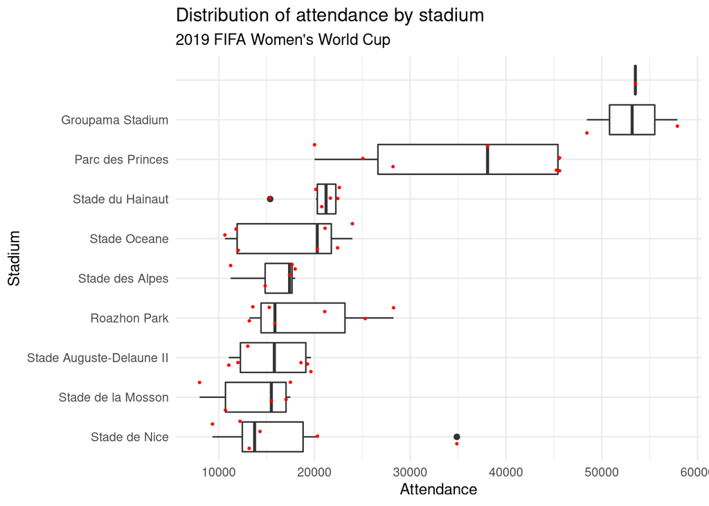

```r
# Housekeeping for plot size
options(repr.plot.width=6, repr.plot.height=4)

# Prettier boxplot of attendance data by venue
wwc_4  %>%
  ggplot(aes(x = forcats::fct_reorder(venue, attendance), y = attendance)) +
    # .... YOUR CODE FOR TASK 8 ....
    # .... YOUR CODE FOR TASK 8 ....
    geom_boxplot() +
    geom_jitter(color = "red", size = 0.5) +
    coord_flip() +
    theme(axis.text.x = element_text(angle = 45, , hjust = 1)) +
    labs(title = "Distribution of attendance by stadium",
         subtitle = "2019 FIFA Women's World Cup",
         x = "Stadium",
         y = "Attendance") +
    theme_minimal()
```

## 9. A pretty line plot

Looks good!

That outlier for Stade de Nice looks a little suspect, but we checked the match reports, and the attendance numbers are correct. The suspect match was [France vs. Norway](https://www.fifa.com/womensworldcup/matches/match/300438220/#match-liveblog) - the home nation favorite drew a large crowd wherever they played!

Now that the data are clean, let’s plot the attendance at each stadium over time so we can tell the boss which stadium had the highest attendance during the tournament.

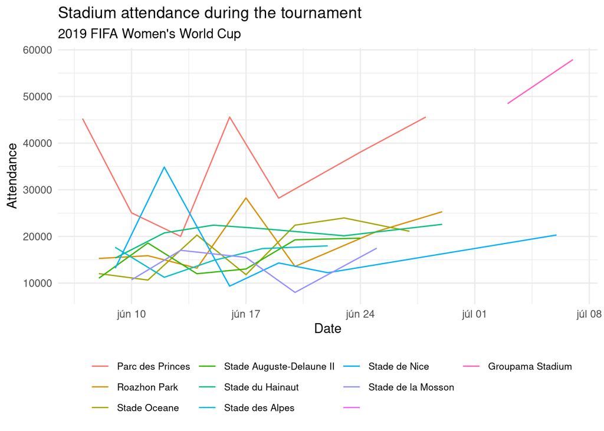

```r
# Housekeeping for plot size
options(repr.plot.width=6, repr.plot.height=4)

# Line plot of attendance over time
wwc_4  %>%
  ggplot(aes(x = date, y = attendance, color = venue)) +
  geom_line() +
   # .... YOUR CODE FOR TASK 8 ....
  theme_minimal() +
  theme(legend.position = "bottom",
       legend.text = element_text(size = 8)) +
  guides(col = guide_legend(nrow = 3)) +
  labs(title = "Stadium attendance during the tournament",
       subtitle = "2019 FIFA Women's World Cup",
       x = "Date",
       y = "Attendance",
      color = "")
```

## 10. Wrap up

Congratulations! You’ve made it to the end of the project.

Great job! We have a couple of beautiful plots to give our boss. With a little more code, we can answer her questions:

1. What match had the highest attendance?
2. In what stadium was the match with the highest attendance played?

```r
# wwc_4 %>% filter(attendance == max(attendance))


# What match had the higest attendance?
# A: wk = SMIF, England vs. USA
# B: wk = FIN, USA vs. Netherlands
# C: wk = SMIF, Netherlands vs. Sweden

ans_1  <- "B"

# In what stadium was the match with the highest attendance played?
# A: Groupama Stadium
# B: Parc des Princes
# C: Stade des Alpes

ans_2  <- "A"
```